# Human Perception of Statistical Charts: An Introduction to Graphical Testing Methods

## Multiplicative Change in Population: Intermediate Q2

*“How many times more [creatures] are there in 40 than in 20?”*

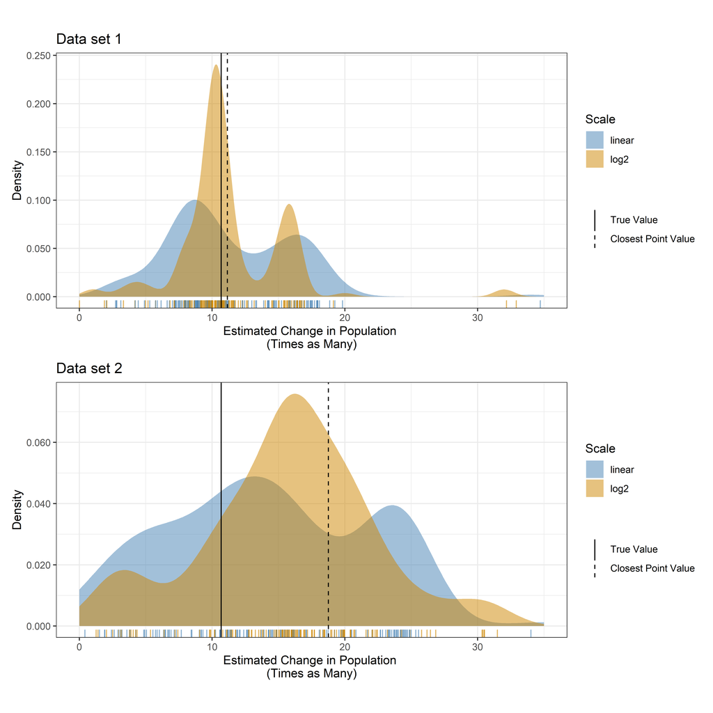

## Conclusions

**1. Perception through Lineups**

- Perceptual differences result from the contextual appearance (depends on choice of scale) of the trends.

**2. Prediction through ‘You Draw It’**

- Clear underestimation of forecasting trends with high exponential growth rates when participants were asked to make predictions on the linear scale.

**3. Numerical Translation and Estimation**

- Log logic is difficult and that we often misinterpret and miscalculate multiplicative reasoning.
- Estimation accuracy for small magnitudes was improved by the use of the log scale, but sacrifices in accuracy on the log scale became apparent as magnitudes increased leading to advantages on the linear scale.

## Overall Recommendations

- Perceptual advantages of the use of log scales due to the change in contextual appearance.
- Our understanding of log logic is flawed when translating the information into context.
- We recommend consideration of both user needs and graph specific tasks when presenting data on the log scale.
- Caution should be taken when interpretation of large magnitudes is required, but advantages may appear when it is necessary to visually identify and interpret small magnitudes on the chart.

## Current Work

- Our recent JDS paper, [*Clusters, Trends, and Choices*](https://doi.org/10.6339/26-JDS1221), explores how viewers use interactive features in statistical lineups.
- The [`youdrawitR` package](https://alisa-krasilnikov.github.io/youdrawitR/) makes drawing tasks available for graphical studies.
- I’m also advising an MS project on data narratives, comparing author-driven and reader-driven approaches, including scrollytelling.

## Emily A. Robinson

### erobin17@calpoly.edu

### github.com/earobinson95

# Additional details

## Lineup Study Design: Curvature Combinations

**Three curvature levels:** low, medium, high.

- $3 \times 2 = 6$ ordered target/comparison combinations.
- Two simulated replicates per combination.
- Both display scales: **24 candidate lineups**.
- **12 evaluations per participant**.

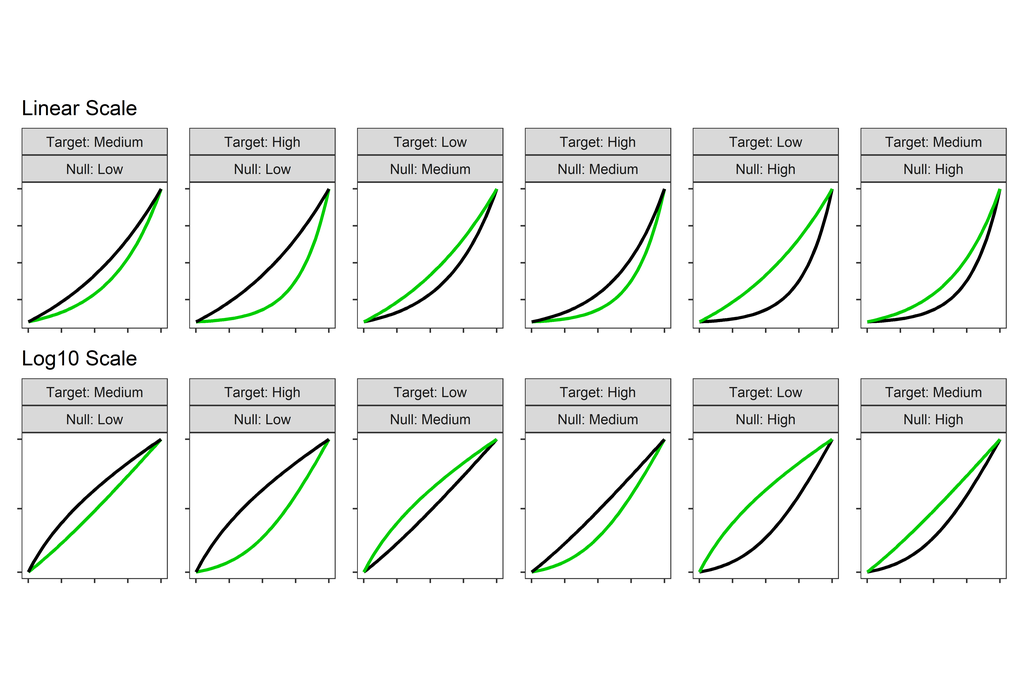

## Generalized Linear Mixed Model

Define $Y_{ijkl}$ to be the event that participant $l$ correctly identifies the target plot for data set $k$ with curvature $j$ plotted on scale $i$.

$$\text{logit }P(Y_{ijk}) = \eta + \delta_i + \gamma_j + \delta \gamma_{ij} + s_l + d_k$$
where:

- $\eta$ is the baseline intercept on the logit scale.
- $\delta_i$ is the effect of the log/linear scale.
- $\gamma_j$ is the effect of the curvature combination.
- $\delta\gamma_{ij}$is the two-way interaction effect of the scale and curvature.
- $s_l \sim N(0,\sigma^2_\text{participant})$, random effect for participant characteristics.
- $d_k \sim N(0,\sigma^2_{\text{data}})$, random effect for data specific characteristics.

We assume that random effects for data set and participant are independent.

## Estimation of Population: Scratch Work

Participant calculations suggest that some viewers equated spatial halfway with numerical halfway.

$$2048-1024=1024$$
$$1024/2=512$$
$$512+1024=1536$$

## Backup: estimation design and simulation

$\alpha=130,\quad\beta=0.12,\quad\theta=50,\quad\sigma=1.5,\quad x\in[0,50]$

- Two data sets share parameters and differ in simulated errors.
- Scale and data set randomly assigned to the two scenarios for each participant.
- Scenario order randomly selected.
- Open-ended question first, followed by randomized quantitative questions.
- Examples and sketches remained available throughout the study.

## Backup: prediction truncation examples

### Low growth · Linear

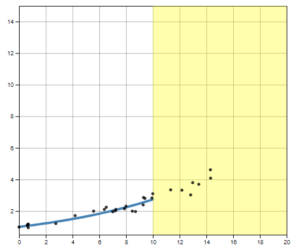

### High growth · Linear

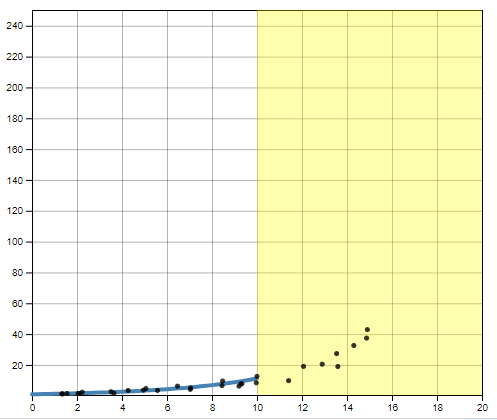

### Low growth · Log

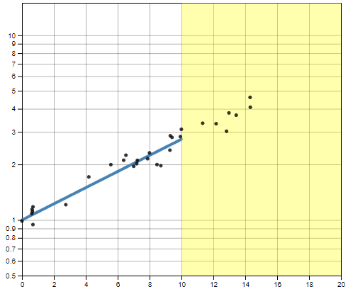

### High growth · Log

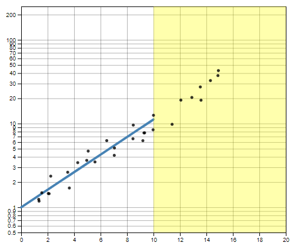

## Backup: first-level estimates across the domain

### Data set 1

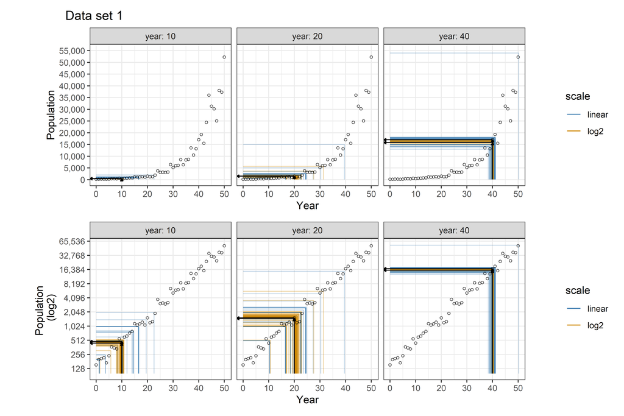

### Data set 2

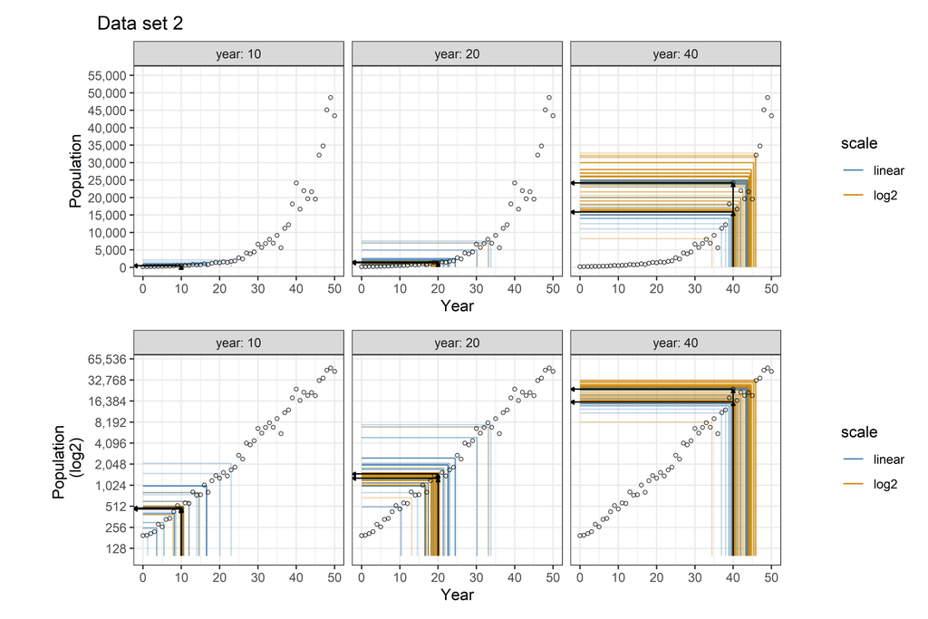

Tick anchoring can create larger numerical errors at larger magnitudes.

## Backup: time until the population doubles

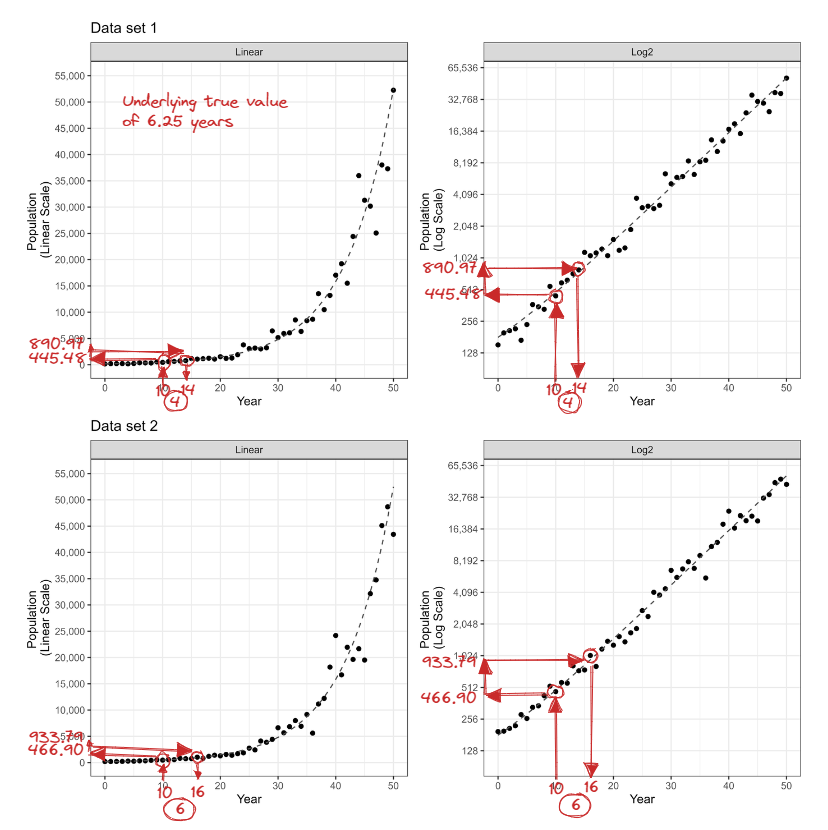

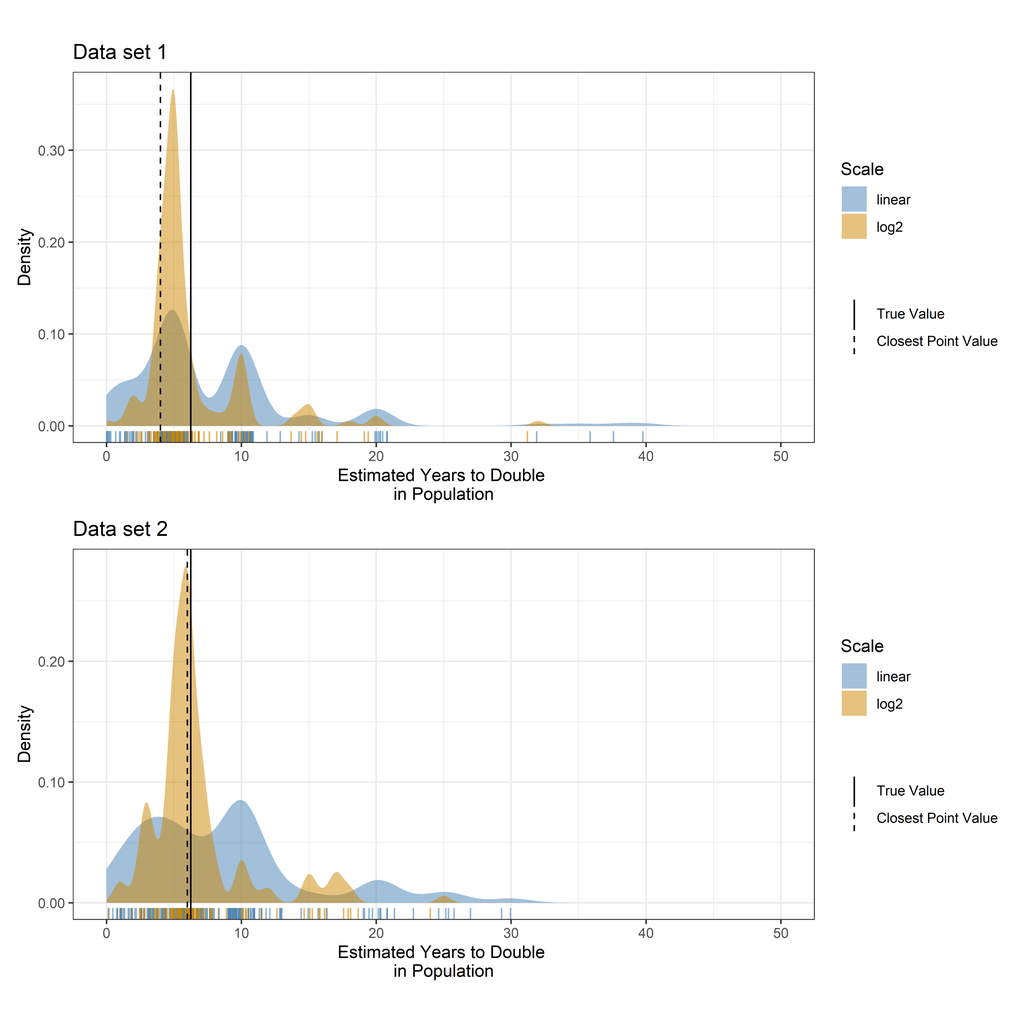

At the year-10 reference, log-scale doubling-time estimates were less variable.

## Backup: additive estimates in the second data set

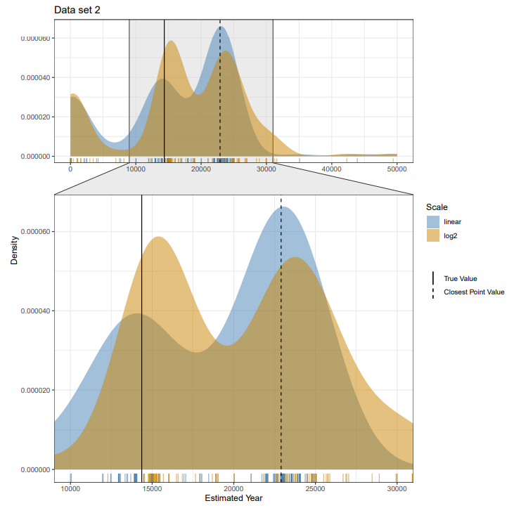

## References

Aisch, Gregor, Nate Cohn, Amanda Cox, Josh Katz, Adam Pearce, and Kevin Quealy. 2016. “Live Presidential Forecast.” In *The New York Times*. The New York Times. https://www.nytimes.com/elections/2016/forecast/president.

Aisch, Gregor, Amanda Cox, and Kevin Quealy. 2015. “You Draw It: How Family Income Predicts Children’s College Chances.” *The New York Times*, May 28. https://www.nytimes.com/interactive/2015/05/28/upshot/you-draw-it-how-family-income-affects-childrens-college-chances.html.

Buja, Andreas, Dianne Cook, Heike Hofmann, et al. 2009. “Statistical Inference for Exploratory Data Analysis and Model Diagnostics.” *Philosophical Transactions of the Royal Society A: Mathematical, Physical and Engineering Sciences* 367 (1906): 4361–83.

Burn-Murdoch, John, Caroline Nevitt, Cale Tilford, et al. 2020. “Coronavirus Tracked: Has the Epidemic Peaked Near You?” In *Coronavirus Chart: See How Your Country Compares*. Financial Times. https://ig.ft.com/coronavirus-chart/?areas=eur.

Carpenter, Patricia A, and Priti Shah. 1988. *A Model of the Perceptual and Conceptual Processes in Graph Comprehension*. 26.

Chandar, Nandini, Deirdre Collier, and Paul Miranti. 2012. “Graph Standardization and Management Accounting at AT&t During the 1920s.” *Accounting History* 17 (1): 35–62.

Fudolig, Miguel Antonio, Emily A. Robinson, and Susan VanderPlas. 2025. “Can You See The Change? Visual Perception in Change Point Analysis.” *Journal of Computational and Graphical Statistics*, ahead of print. https://doi.org/10.1080/10618600.2025.2485278.

Gouretski, Viktor, and Klaus Koltermann. 2007. “How Much Is the Ocean Really Warming?” *Geophysical Research Letters* 34 (1).

Harms, Hans. 1991. “August Friedrich Wilhelm Crome (1753-1833) Autor Begehrter Wirtschaftskarten.” *Cartographica Helvetica* 3: 33–38.

Le, Dylan, Rachel Rogers, and Emily Robinson. 2026. “Clusters, Trends, and Choices: Feature Selection in Interactive Statistical Graphics.” *Journal of Data Science* 24 (2): 352–72. https://doi.org/10.6339/26-JDS1221.

Lewandowsky, Stephan, and Ian Spence. 1989. “The Perception of Statistical Graphs.” *Sociological Methods & Research* 18 (2-3): 200–242. https://doi.org/10.1177/0049124189018002002.

Loy, Adam, Lendie Follett, and Heike Hofmann. 2016. “Variations of q–q Plots: The Power of Our Eyes!” *The American Statistician* 70 (2): 202–14.

Majumder, Mahbubul, Heike Hofmann, and Dianne Cook. 2013. “Validation of Visual Statistical Inference, Applied to Linear Models.” *Journal of the American Statistical Association* 108 (503): 942–56.

Majumder, Mahbubul, Heike Hofmann, and Dianne Cook. 2014. “Human Factors Influencing Visual Statistical Inference.” *arXiv Preprint arXiv:1408.1974*.

Playfair, W. 1801. “The Statistical Breviary; Shewing, on a Principle Entirely New, the Resources of Every State and Kingdom in Europe, Wallis, Londres.” *Press, Chicago*.

Robinson, Emily A, Reka Howard, and Susan VanderPlas. 2022. “Eye Fitting Straight Lines in the Modern Era.” *Journal of Computational and Graphical Statistics*, 1–8.

Robinson, Emily A, Reka Howard, and Susan VanderPlas. 2023. “‘You Draw It’: Implementation of Visually Fitted Trends with R2d3.” *Journal of Data Science* 21 (2): 281–94.

Unwin, Anthony. 2020. “Why Is Data Visualization Important? What Is Important in Data Visualization?” *Harvard Data Science Review*, ahead of print, January 31. https://doi.org/10.1162/99608f92.8ae4d525.

VanderPlas, Susan, and Heike Hofmann. 2015. “Spatial Reasoning and Data Displays.” *IEEE Transactions on Visualization and Computer Graphics* 22 (1): 459–68.

VanderPlas, Susan, and Heike Hofmann. 2017. “Clusters Beat Trend!? Testing Feature Hierarchy in Statistical Graphics.” *Journal of Computational and Graphical Statistics* 26 (2): 231–42.

VanderPlas, Susan, Christian Röttger, Dianne Cook, and Heike Hofmann. 2021. “Statistical Significance Calculations for Scenarios in Visual Inference.” *Stat* 10 (1): e337.

Von Bergmann, Jens. 2021. “Xkcd_exponential: Public Health Vs Scientists.” mountainMath, GitHub, March 17. https://github.com/mountainMath/xkcd_exponential.

Walker, Francis Amasa. 2013. *Statistical Atlas of the United States Based on the Results of the Ninth Census 1870 with Contributions from Many Eminent Men of Science and Several Departments of the Government*. [New York] J. Bien, lith.

Wilkinson, Leland. 2012. *The Grammar of Graphics*. Springer.

Yates, JoAnne. 1985. “Graphs as a Managerial Tool: A Case Study of Du Pont’s Use of Graphs in the Early Twentieth Century.” *The Journal of Business Communication (1973)* 22 (1): 5–33.